# Homework 13

Katarzyna Kanska

21.01.2016

## Goal

We will work with data about previous homeworks.

For each homework let’s count the number of lines in the Rmd file. Then take into account two other variables: the id (number / week) of the homework and the person that is doing the homework.

Create a model that explains the number of lines of homework. What is the relation between number of lines of the homework and the id / week of the homework?

Should the author/submitter be modeled as a fixed or random effect?

## The dataset

Fistly, we cannot just load the dataset. We have to gather this data (for example using some .sh script).

Then we can summarize and plot this data.

```r
results <- read.csv("~/results.csv")
summary(results)
```

```
##     homework           student       lines
##  Min.   : 1.000   bogdanska:15   Min.   : 27.00
##  1st Qu.: 3.000   kanska   :12   1st Qu.: 60.75
##  Median : 5.000   koster   :12   Median : 82.50
##  Mean   : 5.767   obarski  :12   Mean   :101.12
##  3rd Qu.: 9.000   pompe    :12   3rd Qu.:122.25
##  Max.   :12.000   sitko    :12   Max.   :442.00
##                   (Other)  :41
```

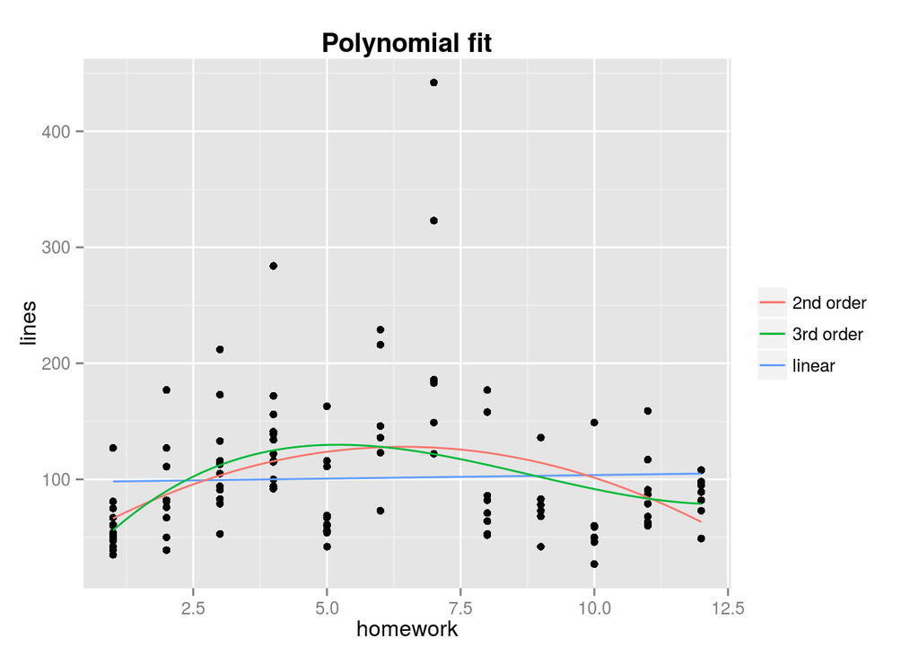

There is no linear relation between `lines` and `homework`. But it is probably worth considering higher order polynomial.

Now let us examine the effect of each student.

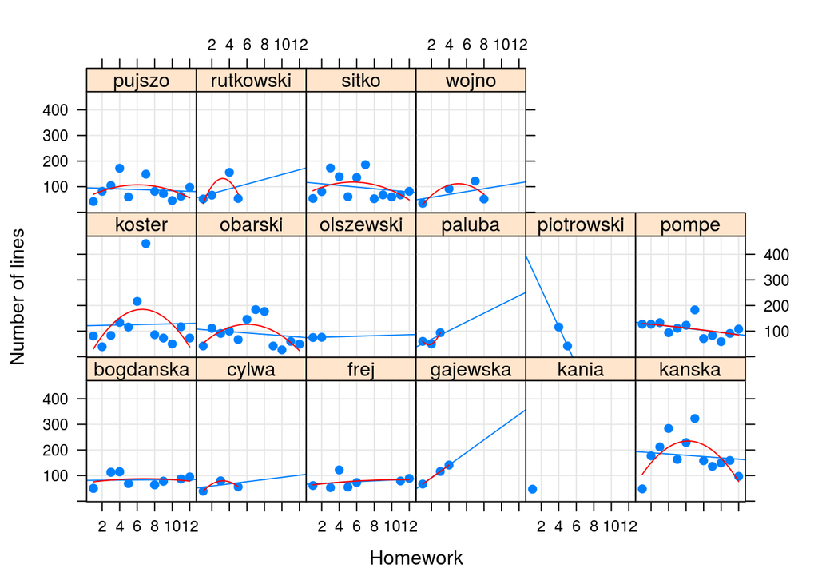

```r
library(lattice)
# panel for lattice package
panel.with.square <- function(...){
  nx = list(...)$x
  ny = list(...)$y
  cc = lm(ny~nx+I(nx^2))$coef
  panel.xyplot(...)
  panel.curve(x^2*cc[3]+x*cc[2]+cc[1], from=min(nx), to=max(nx), col="red")
}
# the plot
xyplot(lines ~ homework | student, results, type = c("g","p","r"),
  xlab = "Homework", ylab = "Number of lines", pch=19,
  panel = panel.with.square)
```

We can see that the effect of `student` should be included. But we also see that not everyone did every homework. From external source of knowledge we can discover that a few people gave up the course. It is not clear if we should include these people in this study during the semester. But let us keep them.

## The linear model

Here we consider two models with `homework` treated as fixed effect (quantitative variable) and `student` as random effect. One of them additionally takes into account the possibility that each student may react differently.

```r
library(lme4)
model1 <- lmer(lines ~ homework + (1|student), data=results)
model2 <- lmer(lines ~ homework + (homework|student), data=results)
```

Now we compare these models.

```r
criteria <- matrix(nrow=2, ncol=2)
criteria[1,] <- c(AIC(model1),BIC(model1))
criteria[2,] <- c(AIC(model2),BIC(model2))
criteria <- data.frame(criteria)
rownames(criteria) <- c("model1", "model2")
colnames(criteria) <- c("AIC", "BIC")
criteria
```

```
##             AIC      BIC
## model1 1271.077 1282.091
## model2 1275.062 1291.584
```

These models seem to be very similar (model1 is slightly better).

Let us briefly check the most crucial assumptions (normality of residuals and random effects).

```r
normality <- matrix(nrow=2, ncol=2)
normality[1,] <- c(shapiro.test(residuals(model1))$p.value,
                   shapiro.test(ranef(model1, condVar=TRUE)$'student'[,1])$p.value)
normality[2,] <- c(shapiro.test(residuals(model2))$p.value,
                   shapiro.test(ranef(model2, condVar=TRUE)$'student'$'(Intercept)')$p.value)
normality<- data.frame(normality)
rownames(normality) <- c("model1", "model2")
colnames(normality) <- c("residuals", "student (mean)")
normality
```

```
##           residuals student (mean)
## model1 1.409312e-10   0.0001296978
## model2 1.349017e-10   0.0001361528
```

Non of these assumptions are met. But it is not that surprising as we already concluded that the relation between `lines` and `homework` is not linear. That is why we try the polynomial fit.

## The polynomial model

As earlier we consider two kinds of relation between `homework` and `student`.

```r
model3 <- lmer(lines ~ homework + I(homework^2) + (1|student), data=results)
model4 <- lmer(lines ~ homework + I(homework^2) + (homework + I(homework^2)|student), data=results)
```

Now we compare these models.

```r
criteria2 <- matrix(nrow=2, ncol=2)
criteria2[1,] <- c(AIC(model3),BIC(model3))
criteria2[2,] <- c(AIC(model4),BIC(model4))
criteria2 <- data.frame(criteria2)
rownames(criteria2) <- c("model3", "model4")
colnames(criteria2) <- c("AIC", "BIC")
criteria2
```

```
##             AIC      BIC
## model3 1253.411 1267.179
## model4 1255.904 1283.440
```

Again model with no relation between `homework` and `student` is slightly better.

Now we check normality assumptions.

```r
normality2 <- matrix(nrow=2, ncol=2)
normality2[1,] <- c(shapiro.test(residuals(model3))$p.value,
                   shapiro.test(ranef(model3, condVar=TRUE)$'student'[,1])$p.value)
normality2[2,] <- c(shapiro.test(residuals(model4))$p.value,
                   shapiro.test(ranef(model4, condVar=TRUE)$'student'$'homework')$p.value)
normality2<- data.frame(normality2)
rownames(normality2) <- c("model3", "model4")
colnames(normality2) <- c("residuals", "student")
normality2
```

```
##           residuals      student
## model3 1.218272e-09 0.0002810974
## model4 7.255795e-09 0.0005430081
```

Again the assumptions are not met.

## No `student` effect?

Maybe there is no `student` effect at all?

```r
model5 <- lm(lines ~ homework, data=results)
model6 <- lm(lines ~ homework + I(homework^2), data=results)
model7 <- lm(lines ~ homework + I(homework^2) + I(homework^3), data=results)
anova(model5, model6)
```

```
## Analysis of Variance Table
##
## Model 1: lines ~ homework
## Model 2: lines ~ homework + I(homework^2)
##   Res.Df    RSS Df Sum of Sq      F    Pr(>F)
## 1    114 421784
## 2    113 363482  1     58302 18.125 4.294e-05 ***
## ---
## Signif. codes:  0 '***' 0.001 '**' 0.01 '*' 0.05 '.' 0.1 ' ' 1
```

```r
anova(model6, model7)
```

```
## Analysis of Variance Table
##
## Model 1: lines ~ homework + I(homework^2)
## Model 2: lines ~ homework + I(homework^2) + I(homework^3)
##   Res.Df    RSS Df Sum of Sq      F  Pr(>F)
## 1    113 363482
## 2    112 354171  1    9310.8 2.9444 0.08894 .
## ---
## Signif. codes:  0 '***' 0.001 '**' 0.01 '*' 0.05 '.' 0.1 ' ' 1
```

Here we see that quadratic relation between `lines` and `homework` is probably the best one.

```r
criteria3 <- matrix(nrow=3, ncol=2)
criteria3[1,] <- c(AIC(model5),BIC(model5))
criteria3[2,] <- c(AIC(model6),BIC(model6))
criteria3[3,] <- c(AIC(model7),BIC(model7))
criteria3 <- data.frame(criteria3)
rownames(criteria3) <- c("linear", "quadratic", "cubic")
colnames(criteria3) <- c("AIC", "BIC")
criteria3
```

```
##                AIC      BIC
## linear    1286.238 1294.499
## quadratic 1270.982 1281.996
## cubic     1269.971 1283.739
```

BIC criterion convince us in this choice.

```r
shapiro.test(rstandard(model5))
```

```
##
##  Shapiro-Wilk normality test
##
## data:  rstandard(model5)
## W = 0.79625, p-value = 2.184e-11
```

```r
shapiro.test(rstandard(model6))
```

```
##
##  Shapiro-Wilk normality test
##
## data:  rstandard(model6)
## W = 0.84891, p-value = 1.587e-09
```

```r
shapiro.test(rstandard(model7))
```

```
##
##  Shapiro-Wilk normality test
##
## data:  rstandard(model7)
## W = 0.83274, p-value = 3.882e-10
```

Once again residuals are not normally distributed.

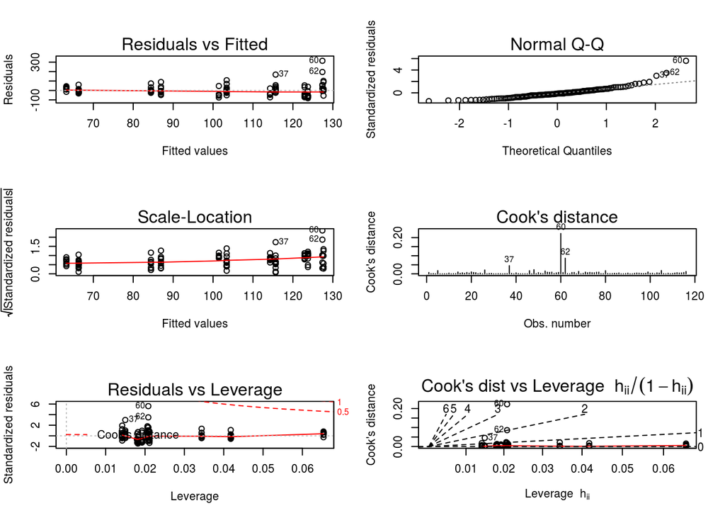

```r
par(mfrow=c(3,2))
plot(model6, which=1:6)
```

Probably the biggest problem is that the residuals have a heavy right tail. There are no influential observations.

Maybe *not really hardworking students* are the problem? Let us remove them from the dataset.

```r
results2 <- results[as.character(results$student) %in% c("bogdanska","frej","gajewska","kanska","koster","obarki","pompe","pujszo","sitko","wojno"),]
results2$student <- factor(results2$student)
```

Does it change anything?

```r
model8 <- lm(lines ~ homework + I(homework^2), data=results2)
shapiro.test(rstandard(model8))
```

```
##
##  Shapiro-Wilk normality test
##
## data:  rstandard(model8)
## W = 0.83613, p-value = 1.855e-08
```

Not really.

## Transformation of the data

We try Box-Cox transformation.

```r
library(MASS)
tmp <- boxcox(lines ~ homework + I(homework^2), data=results, lambda=seq(-1, 1, by=.005))
```

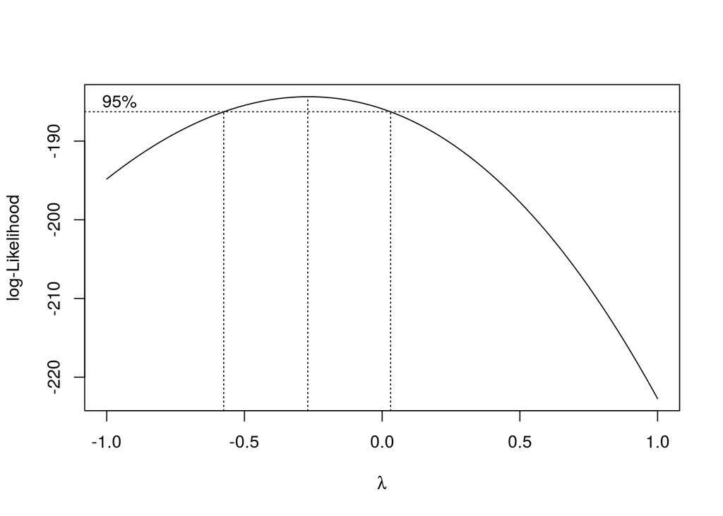

```r
(lambda <- tmp$x[which.max(tmp$y)])
```

```
## [1] -0.27
```

```r
results$linesT <- (results$lines^lambda - 1)/lambda
```

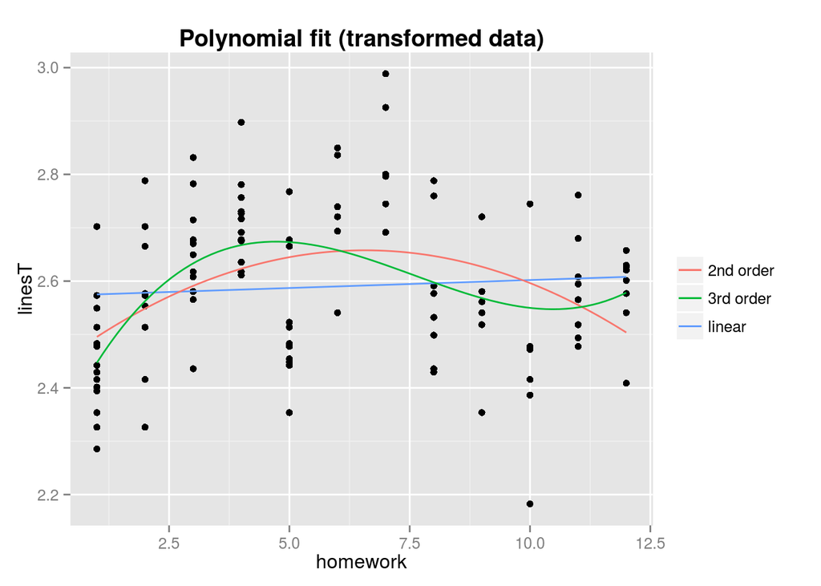

Again we suppose there is 2nd order polynomial relation.

```r
model9 <- lm(linesT ~ homework + I(homework^2), data=results)
shapiro.test(rstandard(model9))
```

```
##
##  Shapiro-Wilk normality test
##
## data:  rstandard(model9)
## W = 0.99098, p-value = 0.6478
```

Now the residuals are normally distributed (we cannot reject the null hypotesis).

## Mixed model once again

Now let us include the effect of `student`.

```r
model10 <- lmer(linesT ~ homework + I(homework^2) + (1|student), data=results)
shapiro.test(residuals(model10))
```

```
##
##  Shapiro-Wilk normality test
##
## data:  residuals(model10)
## W = 0.98368, p-value = 0.1724
```

```r
shapiro.test(ranef(model10, condVar=TRUE)$'student'[,1])
```

```
##
##  Shapiro-Wilk normality test
##
## data:  ranef(model10, condVar = TRUE)$student[, 1]
## W = 0.82585, p-value = 0.006131
```

These results suggest that `student` variable should not be included.

## Final model

```r
summary(model9)
```

```
##
## Call:
## lm(formula = linesT ~ homework + I(homework^2), data = results)
##
## Residuals:
##      Min       1Q   Median       3Q      Max
## -0.41377 -0.10325  0.01751  0.09905  0.33177
##
## Coefficients:
##                Estimate Std. Error t value Pr(>|t|)
## (Intercept)    2.431981   0.040214  60.475  < 2e-16 ***
## homework       0.068717   0.015398   4.463 1.92e-05 ***
## I(homework^2) -0.005228   0.001190  -4.392 2.55e-05 ***
## ---
## Signif. codes:  0 '***' 0.001 '**' 0.01 '*' 0.05 '.' 0.1 ' ' 1
##
## Residual standard error: 0.1375 on 113 degrees of freedom
## Multiple R-squared:  0.1502, Adjusted R-squared:  0.1351
## F-statistic: 9.984 on 2 and 113 DF,  p-value: 0.0001017
```

## Conclusions

- It is recommended to do the graphical analysis in the first places. For example looking at the histogram of `lines` variable could have made us consider the data transformation earlier.
- There is no relation between `lines` and `student`, so there was no need to consider whether I should include myself as a fixed or a random effect.
- There is a non-linear relation between `lines` and `homework`. This implies that simply some homeworks demanded more work than others and it had a very similar impact on all of the students.